# Lab 8.2 Machine Learning 2 – Artificial Neural Network, Classification

### Task 2.2

After finishing training the model so far in the condition below, answer the following questions.

- Acceleration axis: X-axis
- input feature: Raw data (without signal processing as Prelab8)
- Embedding size: 64
- Please specify if you change any hyper-parameters or variables.
1. What is performance of the model? Evaluate and analyze your model including Threshold, Accuracy, Precision, Recall, and so on. How did you determine the threshold?

The threshold was determined was determined using the given rule of thumb based on the histogram of the train loss.

2. Do you think your model is good enough for anomaly detection of the AFF?

No, unfortunately I do not think that the model is good enough for anomoly detection of the AFF.

### Save the model and reload it

After you train a model, you should save the model for implementation in the future.

```python
# create the "models" folder first
model_folder = "models"
if not os.path.exists(model_folder):
    os.mkdir(model_folder)

t = datetime.datetime.now().strftime("%Y%m%d_%H%M%S")
model_identifier = "_lab8_anomaly_x-axis_raw"

# SavedModel directory (NO extension)
export_path = "./models/" + t + model_identifier

# build model (keep)
dummy_input = tf.zeros((1, N_feature))
_ = autoencoder(dummy_input)

# export SavedModel directory
autoencoder.export(export_path)

print("SavedModel exported to:", export_path)
```

[output not shown]

After you save the model, you see the created model directory under 'models/' in your Colab session as in the example below.

[figure not shown]

**If you run this Colab Notebook by mounting your Google Drive OR you run this on your laptop, you can skip this.**

Please note that if you want to reuse the saved model on different computer/platform, **YOU HAVE TO DOWNLOAD IT TO YOUR COMPUTER BEFORE YOU CLOSE THIS COLAB SESSION.** After you close/disconnect this Colab session, the saved model will be disappeared. Run the next code block to download the saved model as a zip file.

```python
## First create a zip file for your saved model directory
## Note that your directory name must be different.
## after -r, the first arg. is the zip file, the second arg. is the target directory
!zip -r "/content/models/20260329_010240_lab8_anomaly_x-axis_raw.zip" \
     "/content/models/220260329_010240_lab8_anomaly_x-axis_raw"
```

[output not shown]

After you run the code block above, you see the created zip file from the saved model as the capture below. Try downloading it on your laptop.

[figure not shown]

Before we wrap up this lab, let's reload the saved model to see if it works.

```python
model_path = "/content/models/20260329_212228_lab8_anomaly_x-axis_raw"

try:
    loaded = tf.saved_model.load(model_path)
    infer = loaded.signatures["serving_default"]

    # simple forward pass to verify functionality
    _ = infer(tf.zeros((1, N_feature)))

    print("Model reload success.")
except Exception as e:
    print("Model reload failed.")
    raise e
```

```
Model reload success.
```

### Task 2.3

The boolean array represents the models classification as normal or abnormal data based on the data. The float array is the model's confidence or normalized scores that this prediction of normal vs. abnormal categorization is correct. These are the expected behavior of a machine learning model.

### Task 2.4

Discuss how to improve the model.

The model could be improved by using a different axis for the data. The model could also be improved by using a larger embedding layer and more epochs which would fit the data a bit more.

### Task 2.5

Model Unit 8 (prelab + lab) by creating a flow diagram that illustrates the logic, sequence, and processes of the unit.

[figure not shown]

## Lab8 Summary and Deliverables

### Deliverable 1 (Do this at home)

Using the given training Python code, find your best model for anomaly detection of the AFF. As a short report including figures, tables, equations, and so on, justify how and why the best model is selected. You have to include the following information. If you need, add code/text blocks.

- Hyper-parameters (Embedded size, batch size, epoch, etc.)
- Threshold of your model and how determined it
- What axis acceleration data is the best?
- Which feature among raw, time domain, and frequency domain is the best?
- Size of the feature
- What are the prediction performances (accuracy, precision, recall)?

```python
### add and use code blocks
```

```python
class DataSet():
  def __init__(self, axis, data_type="raw"):
    # Exploding the values contained in selected column and converting the string values into float values
    df_new = pd.concat([df['Condition'],df[axis].str.split(' ', expand=True).astype(float)], axis=1) # transform space delimited array to each value
    ds = df_new.copy() # make ds by copying df
    #Converting the Classifier into binary values
    ds.loc[df['Condition'] == 'Normal', 'Status'] = 1 # if Condition column is 'Normal', Give 'Status' Column 1
    ds.loc[df['Condition'] == 'Abnormal', 'Status'] = 0 # if Condition column is 'Abnormal', Give 'Status' Column 0
    ds.drop('Condition', axis=1, inplace=True) # drop 'Condition' column (the first column)
    data = ds.values

    # Define Raw data W/O signal processing
    raw_data = data[:,:-1]
    # Labels: The last column
    labels = data[:,-1]

    # get training and test (validation) dataset
    if data_type == "raw":
      input_feature = raw_data
    elif data_type == "time":
      input_feature = timeFeatures(raw_data) # define time domain feature
    elif data_type == "freq":
      input_feature = freqFeatures(raw_data) # define frequency domain feature (DFT)

    train_data, test_data, train_labels, test_labels = train_test_split(
        input_feature, labels, test_size=0.2, random_state=20
    )

    train_data = tensorNormalization(train_data) # Normalizing train data
    test_data = tensorNormalization(test_data) # Normalizing test data

    #Splitting the dataset based on classification: train_labels: Normal, ~train_labels: Abnormal
    train_labels = train_labels.astype(bool) # transform labels as bool (True or False)
    test_labels = test_labels.astype(bool) # in case of 'Normal' it is Ture, if not, False

    normal_train_data = train_data[train_labels] # define normal train data
    normal_test_data = test_data[test_labels] # define normal test data

    anomalous_train_data = train_data[~train_labels] # define abnormal train data
    anomalous_test_data = test_data[~test_labels] # define abnormal test data

    portion_of_anomaly_in_training = 0.1 #10% of training data will be anomalies
    end_size = int(len(normal_train_data)/(10-portion_of_anomaly_in_training*10))
    combined_train_data = np.append(normal_train_data, anomalous_test_data[:end_size], axis=0)

    # Class assignment
    self.normal_train_data = normal_train_data
    self.normal_test_data = normal_test_data
    self.anomalous_train_data = anomalous_train_data
    self.anomalous_test_data = anomalous_test_data
    self.train_data = train_data
    self.test_data = test_data
    self.train_labels = train_labels
    self.test_labels = test_labels
    self.N_feature = input_feature.shape[1] # Make N_feature an instance attribute
```

```python
class AnomalyDetector(Model):
  def __init__(self, embedding_size, n_feature, **kwargs):
    super(AnomalyDetector, self).__init__(**kwargs)
    self.embedding_size = embedding_size
    self.n_feature = n_feature # Store n_feature as an attribute
    self.encoder = tf.keras.Sequential([
      layers.Dense(256, activation="relu"),
      layers.Dense(128, activation="relu"),
      layers.Dense(self.embedding_size, activation="relu")]) # Smallest Layer Defined Here

    self.decoder = tf.keras.Sequential([
      layers.Dense(128, activation="relu"),
      layers.Dense(256, activation="relu"),
      layers.Dense(self.n_feature, activation="sigmoid")]) # Use n_feature here

  def call(self, x):
    encoded = self.encoder(x)
    decoded = self.decoder(encoded)
    return decoded

  def get_config(self):
    config = super().get_config()
    config.update({
        "embedding_size": self.embedding_size,
        "n_feature": self.n_feature,
    })
    return config
```

```python
from tensorflow.keras.callbacks import EarlyStopping
```

```python
def find_best_model(
    embedding_sizes,
    learning_rates,
    batch_sizes,
    epochs_list,
    axes,
    data_types
):
    tf.random.set_seed(42)
    np.random.seed(42)

    best_roc_auc = 0
    best_model = None
    best_params = None

    results = []
    dataset_cache = {}

    for axis in axes:
        for data_type in data_types:
            # Process data better

            key = (axis, data_type)
            if key not in dataset_cache:
                dataset_cache[key] = DataSet(axis, data_type)
            data = dataset_cache[key]
            val_split = 0.5  # split normal_test into val + test-normal
            split_idx = int(len(data.normal_test_data) * val_split)

            normal_val_data = data.normal_test_data[:split_idx]
            normal_test_data = data.normal_test_data[split_idx:]

            # Final test set (balanced)
            test_data = np.concatenate([
                normal_test_data,
                data.anomalous_test_data
            ])

            test_labels = np.concatenate([
                np.zeros(len(normal_test_data)),
                np.ones(len(data.anomalous_test_data))
            ])

            for es in embedding_sizes:
                for lr in learning_rates:
                    for bs in batch_sizes:
                        for ep in epochs_list:

                            tf.keras.backend.clear_session()

                            params = {
                                "Embedding Size": es,
                                "Learning Rate": lr,
                                "Batch Size": bs,
                                "Epoch": ep,
                                "Axis": axis,
                                "Data Type": data_type
                            }

                            print(params)
                            model = AnomalyDetector(es, data.N_feature)
                            model.compile(
                                optimizer=keras.optimizers.Adam(learning_rate=lr),
                                loss='mae'
                            )

                            # Early stopping to reduce time complexity
                            early_stop = EarlyStopping(
                                monitor='val_loss',
                                patience=5,
                                restore_best_weights=True
                            )

                            model.fit(
                                data.normal_train_data,
                                data.normal_train_data,
                                epochs=ep,
                                batch_size=bs,
                                validation_data=(normal_val_data, normal_val_data),
                                shuffle=True,
                                verbose=0,
                                callbacks=[early_stop]
                            )

                            # Model evaluation
                            recon = model.predict(test_data, verbose=0)
                            loss = tf.keras.losses.mae(recon, test_data).numpy()

                            fpr, tpr, _ = roc_curve(test_labels, loss)
                            roc_auc = auc(fpr, tpr)

                            print(f"ROC AUC: {roc_auc:.4f}")

                            results.append({
                                "params": params,
                                "roc_auc": roc_auc
                            })

                            if roc_auc > best_roc_auc:
                                print(f"New best: {roc_auc:.4f}")

                                best_roc_auc = roc_auc
                                best_model = model
                                best_params = params

                                model.save("best_model.h5")

    return best_model, best_params, results
```

### All Grid Search Parameters

The above code combines all of the data processing pipeline, model training, and model validation into a few short functions. Below shows a grid-search approach to optimize the model using the following options:

| Embedding Sizes | 16, 32, 64, 128, 256 |
| --- | --- |
| Learning Rates | 1e-1, 1e-2, 1e-3, 1e-4, 1e-5 |
| Batch Sizes | 16, 32, 64, 128, 256 |
| Epochs | 50, 100, 200, 300 |
| Axes | X, Y, Z |
| Data Types | Raw, Time Domain, Frequency Domain |

I used ChatGPT to optimize my code including postprocessing the data to also generate a validation set, and to include early stopping so that the number of epochs can be limited if additional epochs do not actually improve the model.

The function "find_best_model" iterates through these different combinations and greedily keeps the best parameters and models once they are trained and validated to provide the best possible model for the data.

```python
embedding_size = [16, 32, 64, 128, 256]
learning_rate = [1e-1, 1e-2, 1e-3, 1e-4, 1e-5]
batch_size = [16, 32, 64, 128, 256]
epoch = [50, 100, 200, 300]
axes = ["Xacc array [m/s2]", "Yacc array [m/s2]", "Zacc array [m/s2]"]
data_types = ["raw", "time", "freq"]

best_model, best_param, results = find_best_model(embedding_size, learning_rate, batch_size, epoch, axes, data_types)
```

```
{'Embedding Size': 16, 'Learning Rate': 0.1, 'Batch Size': 16, 'Epoch': 50, 'Axis': 'Xacc array [m/s2]', 'Data Type': 'raw'}
```

[output not shown]

```
ROC AUC: 0.9910
New best: 0.9910
```

[output not shown]

```
{'Embedding Size': 16, 'Learning Rate': 0.1, 'Batch Size': 16, 'Epoch': 100, 'Axis': 'Xacc array [m/s2]', 'Data Type': 'raw'}
ROC AUC: 0.9865
{'Embedding Size': 16, 'Learning Rate': 0.1, 'Batch Size': 16, 'Epoch': 200, 'Axis': 'Xacc array [m/s2]', 'Data Type': 'raw'}
ROC AUC: 0.9865
{'Embedding Size': 16, 'Learning Rate': 0.1, 'Batch Size': 16, 'Epoch': 300, 'Axis': 'Xacc array [m/s2]', 'Data Type': 'raw'}
ROC AUC: 0.9865
{'Embedding Size': 16, 'Learning Rate': 0.1, 'Batch Size': 32, 'Epoch': 50, 'Axis': 'Xacc array [m/s2]', 'Data Type': 'raw'}
ROC AUC: 0.9865
{'Embedding Size': 16, 'Learning Rate': 0.1, 'Batch Size': 32, 'Epoch': 100, 'Axis': 'Xacc array [m/s2]', 'Data Type': 'raw'}
ROC AUC: 0.9865
```

[output not shown]

```
{'Embedding Size': 16, 'Learning Rate': 0.1, 'Batch Size': 32, 'Epoch': 200, 'Axis': 'Xacc array [m/s2]', 'Data Type': 'raw'}
ROC AUC: 0.9865
{'Embedding Size': 16, 'Learning Rate': 0.1, 'Batch Size': 32, 'Epoch': 300, 'Axis': 'Xacc array [m/s2]', 'Data Type': 'raw'}
```

[output not shown]

[output cut: 30 more lines]

[output not shown]

### Hyper Parameters

```python
embedding_size = [24]
learning_rate = [31e-3]
batch_size = [32]
epoch = [200]
axes = ["Yacc array [m/s2]"]
data_types = ["raw"]

best_model, best_param, results = find_best_model(embedding_size, learning_rate, batch_size, epoch, axes, data_types)
```

```
{'Embedding Size': 24, 'Learning Rate': 0.031, 'Batch Size': 32, 'Epoch': 200, 'Axis': 'Yacc array [m/s2]', 'Data Type': 'raw'}
```

[output not shown]

```
ROC AUC: 0.7941
New best: 0.7941
```

### Validation Charts

```
8/8 ━━━━━━━━━━━━━━━━━━━━ 3s 64ms/step - loss: 0.0302 - val_loss: 0.0785
8/8 ━━━━━━━━━━━━━━━━━━━━ 0s 33ms/step - loss: 0.0288 - val_loss: 0.0811
8/8 ━━━━━━━━━━━━━━━━━━━━ 0s 36ms/step - loss: 0.0284 - val_loss: 0.0798
8/8 ━━━━━━━━━━━━━━━━━━━━ 0s 25ms/step - loss: 0.0283 - val_loss: 0.0791
8/8 ━━━━━━━━━━━━━━━━━━━━ 0s 20ms/step - loss: 0.0282 - val_loss: 0.0798
8/8 ━━━━━━━━━━━━━━━━━━━━ 0s 19ms/step - loss: 0.0282 - val_loss: 0.0803
```

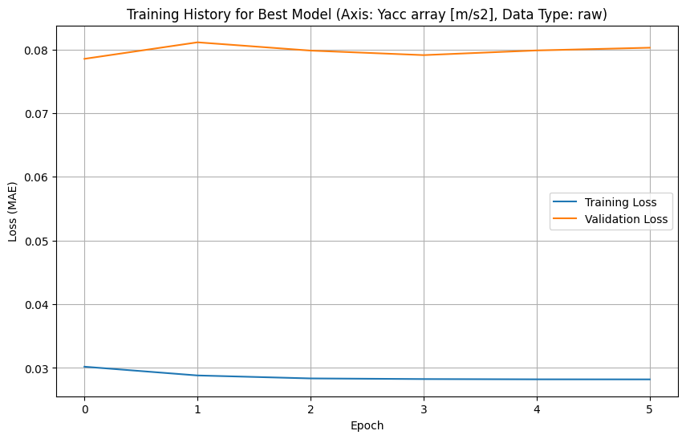

```python
# Recreate the DataSet for the best parameters
best_data = DataSet(best_param["Axis"], best_param["Data Type"])

# Recompile the best_model to prepare it for fitting
best_model.compile(optimizer=keras.optimizers.Adam(learning_rate=best_param["Learning Rate"]), loss='mae')

# Define early stopping as used during the original grid search
early_stop = EarlyStopping(
    monitor='val_loss',
    patience=5,
    restore_best_weights=True
)

# Prepare validation data, as done in find_best_model
val_split = 0.5
split_idx = int(len(best_data.normal_test_data) * val_split)
normal_val_data = best_data.normal_test_data[:split_idx]

# Re-train the best model to capture its training history
history = best_model.fit(
    best_data.normal_train_data,
    best_data.normal_train_data,
    epochs=best_param["Epoch"],
    batch_size=best_param["Batch Size"],
    validation_data=(normal_val_data, normal_val_data),
    shuffle=True,
    verbose=1, # Change to 1 to see training progress
    callbacks=[early_stop]
)

# Plotting the evolution of training and validation loss
plt.figure(figsize=(10, 6))
plt.plot(history.history["loss"], label="Training Loss")
plt.plot(history.history["val_loss"], label="Validation Loss")
plt.title(f"Training History for Best Model (Axis: {best_param['Axis']}, Data Type: {best_param['Data Type']})")
plt.xlabel("Epoch")
plt.ylabel("Loss (MAE)")
plt.legend()
plt.grid(True)
plt.show()
```

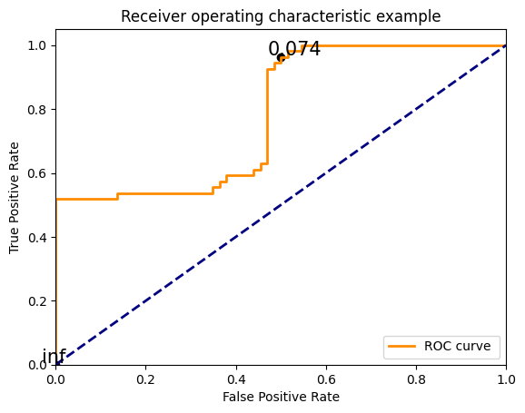

```python
best_data = DataSet(best_param["Axis"], best_param["Data Type"])
reconstructions = best_model(best_data.test_data)
loss = tf.keras.losses.mae(reconstructions, best_data.test_data)

fpr = []
tpr = []
#the test labels are flipped to match how the roc_curve function expects them.
# flipped_labels = 1-test_labels
flipped_labels = 1-test_labels
fpr, tpr, thresholds = roc_curve(flipped_labels, loss)
plt.figure()
lw = 2
plt.plot(fpr, tpr, color='darkorange',
         lw=lw, label='ROC curve ')
plt.plot([0, 1], [0, 1], color='navy', lw=lw, linestyle='--')
plt.xlim([0.0, 1.0])
plt.ylim([0.0, 1.05])
plt.xlabel('False Positive Rate')
plt.ylabel('True Positive Rate')
plt.title('Receiver operating characteristic example')
plt.legend(loc="lower right")

# plot some thresholds
thresholds_every=20
thresholdsLength = len(thresholds)
colorMap=plt.get_cmap('jet', thresholdsLength)
for i in range(0, thresholdsLength, thresholds_every):
  threshold_value_with_max_four_decimals = str(thresholds[i])[:5]
  plt.scatter(fpr[i], tpr[i], c='black')
  plt.text(fpr[i] - 0.03, tpr[i] + 0.005, threshold_value_with_max_four_decimals, fontdict={'size': 15})

plt.show()
```

```python
roc_auc = auc(fpr, tpr) # check roc auc score (the area of roc graph above)
print("ROC - AUC score is {}.".format(roc_auc))
```

```
ROC - AUC score is 0.7836700336700337.
```

#### Histogram of Training Model

```
8/8 ━━━━━━━━━━━━━━━━━━━━ 0s 13ms/step
```

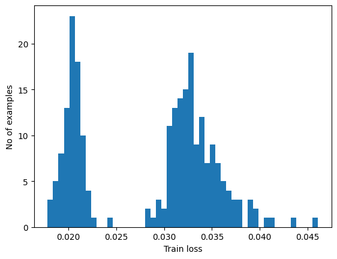

```python
## reconstructions and histogram of training model
reconstructions = best_model.predict(best_data.normal_train_data)
train_loss = tf.keras.losses.mae(reconstructions, best_data.normal_train_data)

plt.hist(train_loss[None,:], bins=50)
plt.xlabel("Train loss")
plt.ylabel("No of examples")
plt.show()
```

```python
# threshold =  #If you want to assign a value labeled in black in the ROC graph  <-----------------------------------------------------------------------------
threshold = np.mean(train_loss) + np.std(train_loss) # Common rule of thumb based on the histogram of the train loss
print("Threshold: ", threshold) # You have to note the threshold you will use
preds, scores = predict(best_model, best_data.test_data, threshold)
print_stats(preds, test_labels)
```

```
Threshold:  0.0354339
Accuracy = 0.55
Precision = 0.55
Recall = 1.0
```

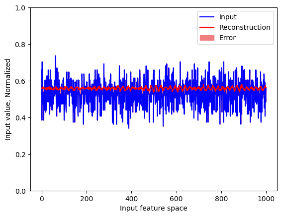

```python
# Plot "Normal" test data sample with reconstruction based on created model and error
encoded_data = autoencoder.encoder(normal_test_data).numpy()
decoded_data = autoencoder.decoder(encoded_data).numpy()

plt.plot(normal_test_data[0], 'b')
plt.plot(decoded_data[0], 'r')
plt.fill_between(np.arange(N_feature), decoded_data[0], normal_test_data[0], color='lightcoral')
plt.ylim([0, 1])
plt.legend(labels=["Input", "Reconstruction", "Error"])
plt.xlabel("Input feature space")
plt.ylabel("Input value, Normalized")
plt.show()
```

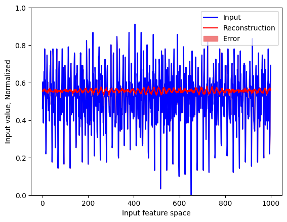

```python
# Plot "Abnormal" test data sample with reconstruction based on created model and error
encoded_data = autoencoder.encoder(anomalous_test_data).numpy()
decoded_data = autoencoder.decoder(encoded_data).numpy()

plt.plot(anomalous_test_data[0], 'b')
plt.plot(decoded_data[0], 'r')
plt.fill_between(np.arange(N_feature), decoded_data[0], anomalous_test_data[0], color='lightcoral')
plt.ylim([0, 1])
plt.legend(labels=["Input", "Reconstruction", "Error"])
plt.xlabel("Input feature space")
plt.ylabel("Input value, Normalized")
plt.show()
```

### Best Model Hyperparameters

[output not shown]

### Deliverable 2

Answer the following questions for your achievements

### Q2. What skills did you have to develop to accomplish this project?

To accomplish this project I had to learn a lot more about machine learning and how to go about training a model. My initial approach was very lengthy and after going to the drawing board and consulting ChatGPT I came up with a better way to automate the fine-tuning of an ML model.

### Q3. What aspects of this project were the most beneficial for your learning?

The aspects of the project that were the most beneficial for my learning were the visualizations of neural networks and being able to play with artificial data and smaller datasets before moving on to performing machine learning on much larger datasets.

### Q4. What challenges did you encounter in completing the project?

The main challenge I encountered while completing the project were that the grid search I initially developed took too long.

### Q5. How did you overcome the challenges or remedy the problems encountered?

After consulting with the TA, I learned that only a few hyperparameters needed to be compared to test and optimize the model. In addition, I did some research online and found a good benchmark rule of thumb ROC score to prevent my model from memorizing the data.

Get back to [Lab Index Page](https://colab.research.google.com/github/purduelamm/purdue_me597_iiot/blob/main/index.ipynb)